# Part I - Possible impact of sociodemographic characteristics on performance of students

## Introduction

The PISA dataset is part of the OECD's Programme for International Student Assessment. OECD is short for 'Organization for Economic Co-operation and Development'. It is a unique forum comprised of the governments of 37 democracies where market-based economies collaborate to develop policy standards so as to promote sustainable economic growth across these countries.

The PISA survey is a survey of students' skills and knowledge as they approach the end of compulsory education. Its main aim is to examine how well students have learned the school curriculum and how well they are prepared for life beyond school.

This danalysis focuses on data collected for the PISA survey of 2012. In this survey, approximately 510,000 students in 65 economies took part in the assessment of reading, mathematics and science. This data represents about 28 million 15-year-olds globally. Of those economies, 44 took part in an assessment of creative problem solving and 18 in an assessment of financial literacy.  
The PISA 2012 dataset is a huge dataset comprising approximately 635 variables however, we shall narrow it down to few variables of interest for this analysis.

## Preliminary Wrangling

In this first section, the data to be used for analysis is programmatically downloaded. Comments describe the process within code cells.

```python
# loading libraries for downloading our dataset into working directory
import os
import requests

# setting url of dataset and saving data as response
url='https://s3.amazonaws.com/udacity-hosted-downloads/ud507/pisa2012.csv.zip'
response=requests.get(url)

# writing data to file name
with open(os.path.basename(url), 'wb') as f:
  f.write(response.content)
```

```python
# Importing zipfile library and unzipping downloaded dataset
import zipfile
with zipfile.ZipFile(os.path.basename(url), 'r') as zf:
    zf.extractall(os.getcwd())
```

```python
#viewing directory and files
os.listdir()
```

```
['pisa2012.csv',
 '.virtual_documents',
 '__notebook_source__.ipynb',
 'samplepsi.csv',
 'pisa2012.csv.zip']
```

```python
# importing all packages and setting plots to be embedded inline
import numpy as np
import pandas as pd
import matplotlib.pyplot as plt
import seaborn as sb

%matplotlib inline
```

```python
# loading data to dataframe with its specific encoding (latin1)
df=pd.read_csv('pisa2012.csv',low_memory=False, encoding='latin1')
```

```python
# viewing a sample of our data
sample=df.sample(5)
sample
```

|  | Unnamed: 0 | CNT | SUBNATIO | STRATUM | OECD | NC | SCHOOLID | STIDSTD | ST01Q01 | ST02Q01 | ... | W_FSTR75 | W_FSTR76 | W_FSTR77 | W_FSTR78 | W_FSTR79 | W_FSTR80 | WVARSTRR | VAR_UNIT | SENWGT_STU | VER_STU |
| --- | --- | --- | --- | --- | --- | --- | --- | --- | --- | --- | --- | --- | --- | --- | --- | --- | --- | --- | --- | --- | --- |
| 178361 | 178362 | Finland | 2460000 | FIN0006 | OECD | Finland | 96 | 2687 | 9 | 1.0 | ... | 20.0305 | 20.0305 | 20.0305 | 18.6200 | 18.6200 | 20.0305 | 31 | 2 | 0.2067 | 22NOV13 |
| 48451 | 48452 | Belgium | 560100 | BEL0108 | OECD | Belgium | 237 | 7065 | 10 | 5.0 | ... | 5.7656 | 5.7656 | 17.2969 | 17.2969 | 18.9458 | 17.2969 | 58 | 1 | 0.1023 | 22NOV13 |
| 321735 | 321736 | Mexico | 4840000 | MEX1852 | OECD | Mexico | 264 | 6033 | 10 | 4.0 | ... | 11.8120 | 3.9373 | 11.8120 | 11.8120 | 11.8120 | 11.8120 | 67 | 1 | 0.0059 | 22NOV13 |
| 452 | 453 | Albania | 80000 | ALB0003 | Non-OECD | Albania | 21 | 453 | 10 | 1.0 | ... | 16.6662 | 5.4494 | 16.6150 | 16.6662 | 5.3447 | 5.2378 | 15 | 2 | 0.2566 | 22NOV13 |
| 258645 | 258646 | Italy | 3800000 | ITA1201 | OECD | Italy | 687 | 18056 | 10 | 1.0 | ... | 3.1286 | 1.0429 | 3.1286 | 3.1286 | 1.0429 | 1.0429 | 12 | 1 | 0.0040 | 22NOV13 |

5 rows × 636 columns

In the cell below, we saved a sample of our data to a csv so we could expand on columns(total 636) using a spreedsheet program, so that we can select our data(columns) of interest.

```python
# saving sample data to csv
sample.to_csv('samplepsi.csv')
```

In the cell below, we selected our variables of interest from our more than 600 variables and narrowed them down to 18 variables. we further renamed them to more descriptive names. The data dictionary of descriptions to variables can be seen **[HERE](https://s3.amazonaws.com/udacity-hosted-downloads/ud507/pisadict2012.csv)**.

```python
# selecting variables of interest
dfi_psi=df[['CNT','OECD','ST01Q01','ST02Q01','ST04Q01','ST06Q01','ST09Q01','ST07Q01','ST13Q01','ST11Q02','ST17Q01','ST85Q03','ST76Q02','ST61Q01','PV1READ','ST88Q02','ST93Q01','W_FSTUWT']].copy()

# renaming variables of interest to more descriptive names
dfi_psi.rename(columns={'CNT':'Country',
                        'OECD':'OECD Country status',
                        'ST01Q01':'International grade',
                        'ST02Q01':'Birth year',
                        'ST04Q01':'Gender',
                        'ST06Q01':'Primary education start age',
                        'ST09Q01':'Truancy of skiping school',
                        'ST07Q01':'Repeat class',
                        'ST13Q01':'Mother education',
                        'ST11Q02':'Living with father',
                        'ST17Q01':'Father education',
                        'ST85Q03':'Teacher start class on time',
                        'ST76Q02':'Math reasoning(maths stength)',
                        'ST61Q01':'Math experience(Use)',
                        'PV1READ':'Reading strength',
                        'ST88Q02':'School attitude(time waste)',
                        'ST93Q01':'Perseverance(tendency to giveup)',
                        'W_FSTUWT':'Weighted student score'},inplace=True)
```

In The cell below, we used the info method to have a general overview of our dataset of interest. It should be noted that the info method could not be run on the main dataset as this previously consumed all memory resources due to the enomosity of this dataset, however, our dataset of interest is within the memory limits of kaggle.

```python
# having a general view of our data and its structure
dfi_psi.info()
```

```
<class 'pandas.core.frame.DataFrame'>
RangeIndex: 485490 entries, 0 to 485489
Data columns (total 18 columns):
 #   Column                            Non-Null Count   Dtype
---  ------                            --------------   -----
 0   Country                           485490 non-null  object
 1   OECD Country status               485490 non-null  object
 2   International grade               485490 non-null  int64
 3   Birth year                        485438 non-null  float64
 4   Gender                            485490 non-null  object
 5   Primary education start age       457994 non-null  float64
 6   Truancy of skiping school         479131 non-null  object
 7   Repeat class                      436690 non-null  object
 8   Mother education                  457979 non-null  object
 9   Living with father                441036 non-null  object
 10  Father education                  443261 non-null  object
 11  Teacher start class on time       311832 non-null  object
 12  Math reasoning(maths stength)     308489 non-null  object
 13  Math experience(Use)              312799 non-null  object
 14  Reading strength                  485490 non-null  float64
 15  School attitude(time waste)       310964 non-null  object
 16  Perseverance(tendency to giveup)  312856 non-null  object
 17  Weighted student score            485490 non-null  float64
dtypes: float64(4), int64(1), object(13)
memory usage: 66.7+ MB
```

```python
# review of the number of unique values under each variable
dfi_psi.nunique()
```

```
Country                                68
OECD Country status                     2
International grade                     8
Birth year                             25
Gender                                  2
Primary education start age            13
Truancy of skiping school               4
Repeat class                            3
Mother education                        5
Living with father                      2
Father education                        5
Teacher start class on time             4
Math reasoning(maths stength)           4
Math experience(Use)                    4
Reading strength                    11556
School attitude(time waste)             4
Perseverance(tendency to giveup)        5
Weighted student score              39393
dtype: int64
```

```python
# running the describe method to better undertand seemingly quantitative type variables
dfi_psi.describe()
```

|  | International grade | Birth year | Primary education start age | Reading strength | Weighted student score |
| --- | --- | --- | --- | --- | --- |
| count | 485490.000000 | 485438.000000 | 457994.000000 | 485490.000000 | 485490.000000 |
| mean | 9.813323 | 2.579260 | 6.148963 | 472.004640 | 50.919113 |
| std | 3.734726 | 2.694013 | 0.970693 | 102.505523 | 107.382092 |
| min | 7.000000 | 1.000000 | 4.000000 | 0.083400 | 1.000000 |
| 25% | 9.000000 | 1.000000 | 6.000000 | 403.600700 | 6.386300 |
| 50% | 10.000000 | 1.000000 | 6.000000 | 475.455000 | 15.782900 |
| 75% | 10.000000 | 3.000000 | 7.000000 | 544.502500 | 44.473300 |
| max | 96.000000 | 25.000000 | 16.000000 | 904.802600 | 2597.884400 |

```python
# reviewing value counts on the country variable
dfi_psi.Country.value_counts()
```

```
Mexico                      33806
Italy                       31073
Spain                       25313
Canada                      21544
Brazil                      19204
                            ...
Florida (USA)                1896
Perm(Russian Federation)     1761
Massachusetts (USA)          1723
Connecticut (USA)            1697
Liechtenstein                 293
Name: Country, Length: 68, dtype: int64
```

```python
# overview of the Birth year variable
dfi_psi['Birth year'].value_counts()
```

```
1.0     243377
2.0      97360
3.0      44739
5.0      29094
4.0      20368
7.0      13901
6.0      11862
11.0     11740
8.0       5558
15.0      2089
9.0       1033
12.0       779
21.0       714
10.0       713
17.0       584
18.0       352
23.0       289
16.0       231
22.0       179
14.0       146
13.0       128
20.0        93
24.0        84
19.0        21
25.0         4
Name: Birth year, dtype: int64
```

```python
# overview of the null variables
dfi_psi.isnull().sum()
```

```
Country                                  0
OECD Country status                      0
International grade                      0
Birth year                              52
Gender                                   0
Primary education start age          27496
Truancy of skiping school             6359
Repeat class                         48800
Mother education                     27511
Living with father                   44454
Father education                     42229
Teacher start class on time         173658
Math reasoning(maths stength)       177001
Math experience(Use)                172691
Reading strength                         0
School attitude(time waste)         174526
Perseverance(tendency to giveup)    172634
Weighted student score                   0
dtype: int64
```

As seen in the cell below, 11 duplicates are contained within this dataset. The cell after it adresses the situation.

```python
#checking for duplicates
dfi_psi.duplicated().sum()
```

```
11
```

```python
#dropping duplicates and confirming drop
dfi_psi.drop_duplicates(inplace=True)

# an empty dataframe without rows is shown below, meaning thereare no further duplicates
dfi_psi[dfi_psi.duplicated()==True]
```

|  | Country | OECD Country status | International grade | Birth year | Gender | Primary education start age | Truancy of skiping school | Repeat class | Mother education | Living with father | Father education | Teacher start class on time | Math reasoning(maths stength) | Math experience(Use) | Reading strength | School attitude(time waste) | Perseverance(tendency to giveup) | Weighted student score |
| --- | --- | --- | --- | --- | --- | --- | --- | --- | --- | --- | --- | --- | --- | --- | --- | --- | --- | --- |

```python
# reveiwing the start time of teacher variable
dfi_psi['Teacher start class on time'].value_counts()
```

```
Agree                143773
Strongly agree       110023
Disagree              47626
Strongly disagree     10409
Name: Teacher start class on time, dtype: int64
```

```python
# reviewing the international grade variable
dfi_psi['International grade'].value_counts()
```

```
10    262622
9     152849
11     38396
8      23764
7       3536
12      3436
96       873
13         3
Name: International grade, dtype: int64
```

The cell below summarises majority of categorical variables such that their nature is observed for any further cleaning. From the nature of the variable categories, not much cleaning is neccesary as there are no categories with issues such as typos.

```python
# selecting variables to sumarise
sumcat=['OECD Country status','Gender','Primary education start age','Truancy of skiping school','Repeat class','Mother education','Living with father','Father education','Teacher start class on time','Math reasoning(maths stength)','Math experience(Use)','School attitude(time waste)','Perseverance(tendency to giveup)']

# summarising variables with apply and value counts, then stacking them for a concise and general understanding of many variables at once
summary_categories=pd.DataFrame(dfi_psi[sumcat].apply(lambda x:x.value_counts()).T.stack(),columns=['Frequency'])
summary_categories
```

|  |  | Frequency |
| --- | --- | --- |
| OECD Country status | Non-OECD | 190073.0 |
|  | OECD | 295406.0 |
| Gender | Female | 245056.0 |
|  | Male | 240423.0 |
| Primary education start age | 4.0 | 14089.0 |
|  | 5.0 | 70216.0 |
|  | 6.0 | 235688.0 |
|  | 7.0 | 125794.0 |
|  | 8.0 | 7275.0 |
|  | 9.0 | 1048.0 |
|  | 10.0 | 949.0 |
|  | 11.0 | 1125.0 |
|  | 12.0 | 607.0 |
|  | 13.0 | 315.0 |
|  | 14.0 | 259.0 |
|  | 15.0 | 472.0 |
|  | 16.0 | 154.0 |
| Truancy of skiping school | Five or more times | 6282.0 |
|  | None | 385995.0 |
|  | One or two times | 75969.0 |
|  | Three or four times | 10882.0 |
| Repeat class | No, never | 401261.0 |
|  | Yes, once | 30709.0 |
|  | Yes, twice or more | 4717.0 |
| Mother education | <ISCED level 1> | 36556.0 |
|  | <ISCED level 2> | 82613.0 |
|  | <ISCED level 3A> | 236991.0 |
|  | <ISCED level 3B, 3C> | 83048.0 |
|  | She did not complete <ISCED level 1> | 18768.0 |
| Living with father | No | 68875.0 |
|  | Yes | 372158.0 |
| Father education | <ISCED level 1> | 35938.0 |
|  | <ISCED level 2> | 84328.0 |
|  | <ISCED level 3A> | 215278.0 |
|  | <ISCED level 3B, 3C> | 91179.0 |
|  | He did not complete <ISCED level 1> | 16535.0 |
| Teacher start class on time | Agree | 143773.0 |
|  | Disagree | 47626.0 |
|  | Strongly agree | 110023.0 |
|  | Strongly disagree | 10409.0 |
| Math reasoning(maths stength) | Frequently | 54701.0 |
|  | Never | 39947.0 |
|  | Rarely | 88556.0 |
|  | Sometimes | 125284.0 |
| Math experience(Use) | Frequently | 53983.0 |
|  | Never | 52465.0 |
|  | Rarely | 80427.0 |
|  | Sometimes | 125923.0 |
| School attitude(time waste) | Agree | 25060.0 |
|  | Disagree | 154331.0 |
|  | Strongly agree | 11433.0 |
|  | Strongly disagree | 120139.0 |
| Perseverance(tendency to giveup) | Mostly like me | 34137.0 |
|  | Not at all like me | 67815.0 |
|  | Not much like me | 109280.0 |
|  | Somewhat like me | 78831.0 |
|  | Very much like me | 22791.0 |

### What is/are the main feature(s) of interest in your dataset?

My singled out dataset consist of sociodemographic characteristics associated with students and variables that assess characteristics such as their reading strength, maths ability. I shall be interested in the association between their abilities and sociodemographic factors like country of participant, Gender etc.

### What features in the dataset do you think will help support your investigation into your feature(s) of interest?

Variables like the student weight score which determines the overall strength of students across categories shall be imperative in determining if a student is estimated to be successful or not. Math experience,reading strength as well as their attitudes shall be compared to characteristics like their Gender, as well as other sociodemographic variables.

## Univariate Exploration

Exploring single variables of interest.

**Question 1:**  
What are the top 5 countries that participated most in the PISA survey.  
**Visualisation :**

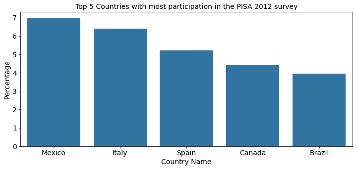

```python
# Top 5 countries summary
summary_p=dfi_psi.Country.value_counts(normalize=True)*100
summary_p=summary_p.head(5)

# Method that plots a bar chart given a summary of the data
def sumbar(summary_p,title,xlabel,ylabel):
    plt.figure(figsize=[12,5])
    ind=summary_p.index
    vl=summary_p.values
    sb.barplot(x=ind,y=vl,color=sb.color_palette()[0])
    plt.title(title,fontsize=14)
    plt.xlabel(xlabel,fontsize=14)
    plt.ylabel(ylabel,fontsize=14)
    plt.xticks(fontsize=14)
    plt.yticks(fontsize=14)

# plotting bar given title and axis values
title='Top 5 Countries with most participation in the PISA 2012 survey'
sumbar(summary_p,title,'Country Name','Percentage')
```

**Question 2:**  
What is the percentage of males to females that participated in the PISA 2012 survey.  
**Visualisation :**

```
Female    50.48
Male      49.52
Name: Gender, dtype: float64
```

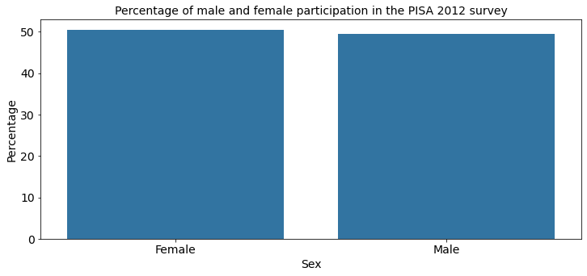

```python
# Summary of participant'sexs with a print out
summary_p=dfi_psi.Gender.value_counts(normalize=True)*100
print(summary_p.round(2))

# plotting a bar of sexes using the sumbar method earlier defined
title='Percentage of male and female participation in the PISA 2012 survey'
sumbar(summary_p,title,'Sex','Percentage')
```

**Observation**  
From the bar chart above, it can be seen that there was almost similar participation between sexes with just barely noticeable difference between male and female participation.

**Question 3**  
What is the percentage of participants in the study who are OECD registered versus those who are not?  
**Visualisation :**

```
OECD        60.85
Non-OECD    39.15
Name: OECD Country status, dtype: float64
```

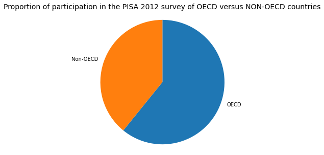

```python
# summary OECD country status data with printed percent
oecd_counts = dfi_psi['OECD Country status'].value_counts(normalize=True)
print((oecd_counts*100).round(2))

# Method below plots a pie charts
def sumpie(oecd_counts,title):
    plt.figure(figsize=[12,5])
    plt.pie(oecd_counts, labels = oecd_counts.index, startangle = 90,
        counterclock = False);
    plt.title(title,fontsize=14)
    plt.axis('square')


# plotting chart with the sumpie method
title='Proportion of participation in the PISA 2012 survey of OECD versus NON-OECD countries'
sumpie(oecd_counts,title)
```

**observation**  
From the pie chart above, it can be observed that more than 50% of participants that took part in this study were from OECD countries.

**Question 4**  
Of all the participants in this survey, what is the nature of class repetition?  
**Visualisation :**

```
No, never             91.89
Yes, once              7.03
Yes, twice or more     1.08
Name: Repeat class, dtype: float64
```

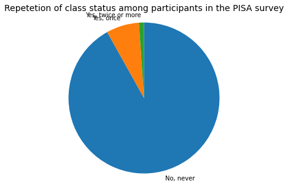

```python
# summary OECD country status data with printred percent
rep_counts = dfi_psi['Repeat class'].value_counts(normalize=True)
print((rep_counts*100).round(2))

#Plotting pie chart on repetition status using the sumpie method
title='Repetetion of class status among participants in the PISA survey'
sumpie(rep_counts,title)
```

**Observation**  
From the pie chart above, it can be observed that an overwelming number of students have never repeated a class compared followed by a a relatively small number who have repeated once to a very small percent who have repaeated more than once. Labels seem to almost overlap but since this is just exploratory analysis, we shall leave that to slide.

**Question 5**  
What is proportion of children who are in their homes with their fathers?  
**Visualisation :**

```
Yes    84.38
No     15.62
Name: Living with father, dtype: float64
```

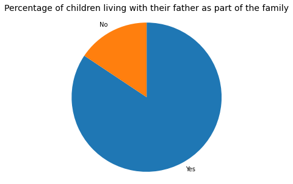

```python
# summary Oof children living with parents in the PiSA dataset
lf_counts = dfi_psi['Living with father'].value_counts(normalize=True)
print((lf_counts*100).round(2))

#Plotting pie chart on children living with their father using the sumpie method
title='Percentage of children living with their father as part of the family'
sumpie(lf_counts,title)
```

**Observation**  
From the pie chart above, it can be observed that a relatively large proportion of children(more than 75%) have the active participation of their fathers in their lives.

**Question 6**  
What is the distribution of PISA participant's Reading strenght?  
**Visualisation :**

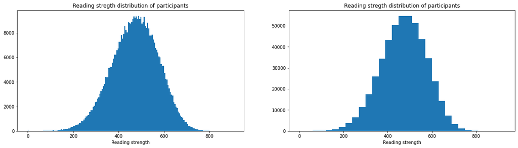

```python
# method to plot a histogram given the variable and bin step
def hisp(var,title,bins):
  # data setup for histogram
    bins = np.arange(0, dfi_psi[var].max()+bins, bins)
    plt.hist(data=dfi_psi,x=var, bins = bins)
    plt.title(title)
    plt.xlabel(var)

#plotting a histogram chart of participants reading strenght using the hisp method

title='Reading stregth distribution of participants'
# Plotting bars with different bin sizes using subplots
plt.figure(figsize = [20, 5])
plt.subplot(1, 2, 1)
hisp('Reading strength',title,5)

plt.subplot(1, 2, 2)
hisp('Reading strength',title,30)
```

**Observation**  
From the chart above, it can be seen that both graphs show a relatively normal distribution implying there is a normal distrubution of reading strength across all participating countries.

**Question 7**  
What is the distribution of PISA participant's Weighted student score?  
**Visualisation :**

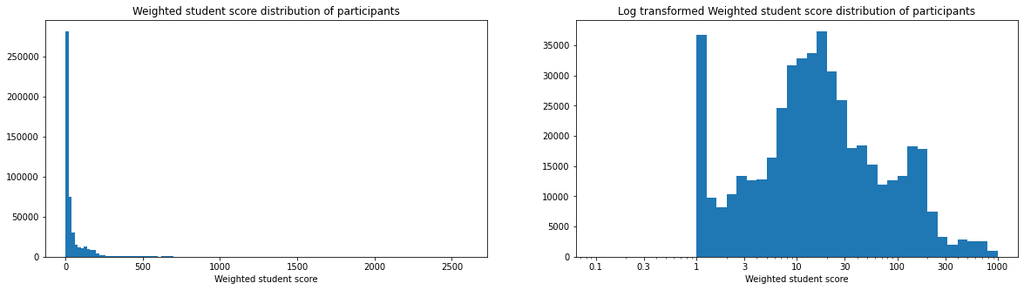

```python
# log transfomed and scaled histogram plotting method
def histransformed(var,title):
  # data setup for histogram
    bins = 10 ** np.arange(-1, 3+0.1, 0.1)
    plt.hist(data=dfi_psi,x=var, bins = bins)
    plt.title(title)
    plt.xlabel(var)
    plt.xscale('log')
    ticks = [0.1, 0.3, 1, 3, 10, 30, 100, 300, 1000]
    labels = ['{}'.format(v) for v in ticks]
    plt.xticks(ticks,labels)

#plotting a histogram chart of participants reading strenght using the hisp and histransformed method

title='Weighted student score distribution of participants'
# Plotting bars with different bin sizes using subplots
plt.figure(figsize = [20, 5])
plt.subplot(1, 2, 1)
hisp('Weighted student score',title,20)
#plotting transformed subplot
plt.subplot(1, 2, 2)
histransformed('Weighted student score','Log transformed Weighted student score distribution of participants')
```

**Observation**  
From the chart above, it is observed that the data seemed skewed to the right with seeemingly poor construction of the chart with many outliers. The log transformation addressed this issue and a bimodal nature was observed as well as right skewedness.

**Question 8**  
What is the nature of class skipping among students?  
**Visualisation :**

```
Never skips classes    80.56
One or two times       15.86
Three or four times     2.27
Five or more times      1.31
Name: Truancy of skiping school, dtype: float64
```

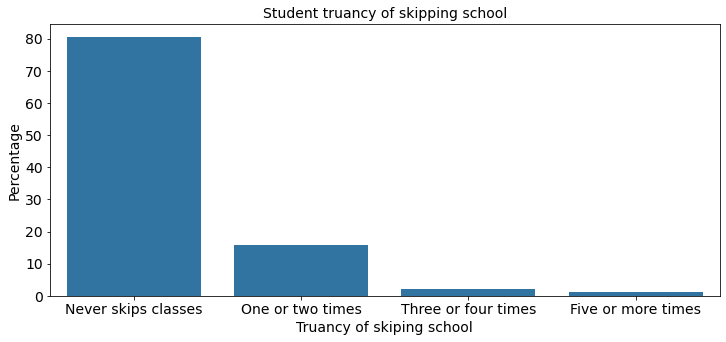

```python
#Function to plot ordinal bar charts for our ordinal variables taking in
def ordbar(var,title,xlabel,ylabel,order):
    plt.figure(figsize=[12,5])
    ind=summary_p.index
    vl=summary_p.values
    sb.barplot(x=ind,y=vl,color=sb.color_palette()[0],order=order)
    plt.title(title,fontsize=14)
    plt.xlabel(xlabel,fontsize=14)
    plt.ylabel(ylabel,fontsize=14)
    plt.xticks(fontsize=14)
    plt.yticks(fontsize=14)


# plotting bar given title and axis values
title='Student truancy of skipping school'

#renaming category of None
dfi_psi['Truancy of skiping school']=dfi_psi['Truancy of skiping school'].str.replace('None','Never skips classes')

#removing spaces at end of various categories
dfi_psi['Truancy of skiping school']=dfi_psi['Truancy of skiping school'].str[:-2]

# defining order or ordinal variables and summarising data
order=['Never skips classes','One or two times','Three or four times','Five or more times']
summary_p=dfi_psi['Truancy of skiping school'].value_counts(normalize=True)*100
dfi_psi['Truancy of skiping school'].value_counts(normalize=True)*100
print(summary_p.round(2))

#plotting ordinal chart
ordbar(summary_p,title,'Truancy of skiping school','Percentage',order)
```

**Observation**  
From the chart above, it can be observed that approximately 80% of students do not skip classes and class skipping reduces with the number of skips

**Question 9**  
What are the studenst impression on the timely start of classes by students?  
**Visualisation :**

```
Agree                46.11
Strongly agree       35.28
Disagree             15.27
Strongly disagree     3.34
Name: Teacher start class on time, dtype: float64
```

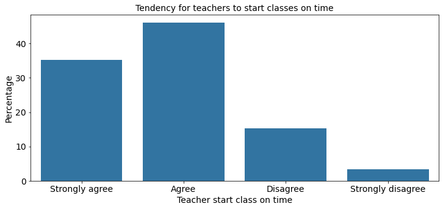

```python
# plotting otrdinal representation of studenst impression on school timeliness by teachers using the ordbar method

#summarising data
summary_p=dfi_psi['Teacher start class on time'].value_counts(normalize=True)*100
print(summary_p.round(2))

# Setting order, title and plotting using the ordbar method
title='Tendency for teachers to start classes on time'
order=['Strongly agree','Agree','Disagree','Strongly disagree']
ordbar(summary_p,title,'Teacher start class on time','Percentage',order=order)
```

**Observation**  
From the dataset above, it can be observed that approximately 35% of students strongly agree that their teachers start classes on time. A generally higher percerntage is seen among those who just agree and on the diagreement trend, a drop is observed form those diagreeing to strongly diagreeing.

**Question 10**  
What is the level of effort that students put in to reason mathematics?  
**Visualisation :**

```
Sometimes     40.61
Rarely        28.71
Frequently    17.73
Never         12.95
Name: Math reasoning(maths stength), dtype: float64
```

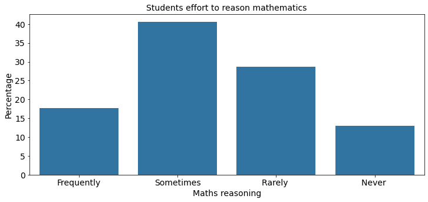

```python
# summarising data
summary_p=dfi_psi['Math reasoning(maths stength)'].value_counts(normalize=True)*100
print(summary_p.round(2))

#defining title and summarising data
title='Students effort to reason mathematics'
order=['Frequently','Sometimes','Rarely ','Never ']

# drawing ordinal bar using the ordbar method
ordbar(summary_p,title,'Maths reasoning','Percentage',order)
```

**Observation**  
From the chart above, it can be seen that approximately 17.5 % of students frequently engage in reasoning mathematics. This percentage jumps up approximately 40% who sometimes reason and a reduction is faced from there to those who never reason(Do not make any effort to reason).

**Question 11**  
What is the distribution and studenst view about school being a waste of time?  
**Visualisation :**

```
Disagree             49.63
Strongly disagree    38.63
Agree                 8.06
Strongly agree        3.68
Name: School attitude(time waste), dtype: float64
```

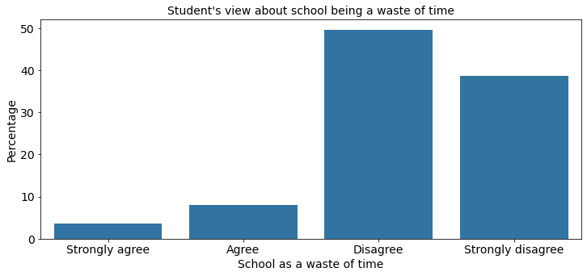

```python
# plotting ordinal representation of studenst impression on school being a waste of time using the ordbar method

#summarising data
summary_p=dfi_psi['School attitude(time waste)'].value_counts(normalize=True)*100
print(summary_p.round(2))

# Setting order, title and plotting
title='Student\'s view about school being a waste of time'
order=['Strongly agree','Agree','Disagree','Strongly disagree']
ordbar(summary_p,title,'School as a waste of time','Percentage',order)
```

### Discuss the distribution(s) of your variable(s) of interest. Were there any unusual points? Did you need to perform any transformations?

Majority of our variables of interest were normal and ordinal variables and they often showed farely predictable patherns in the distribution of their categories. We visualised two continuous variables that sought to communicate the reading strenth of participants and their weighted score. The normal distribution was observed in the variable that looked at students reading strengths while a right skewed graph was observed on the weightedscore of studenstacross categories. For the weighted score, a log transformation and scaling was done in other to generate a farely legible and more appreciable graph.

### Of the features you investigated, were there any unusual distributions? Did you perform any operations on the data to tidy, adjust, or change the form of the data? If so, why did you do this?

On the weighted student score, a right skewed observation was seen and the graph had to be transformed in other for a more representable observation to be seen. No tidying was done in the data as it came in a tidy format however, data quality issues such modifying string values for appropriate analysing and representation was doen. This can be see on the variable on truancy, in whhich spaces were removed infront of the various categories and a renaming was also done to have a more representative category.

## Bivariate Exploration

Exploring the relationships between pairs of variables of interest.

**Question 12**  
What is the correlation between student reading strenght and weighted score predicting their possible success in life?  
**Visualisation :**

```
Correlation coefficient -0.04
```

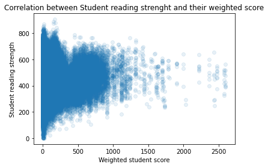

```python
# method to plot correlation between two variable while computing their Correlatio coefficient along
def corrp(x,y,xlabel,ylabel):
    ccoefficient=dfi_psi[x].corr(dfi_psi[y])
    print('Correlation coefficient',ccoefficient.round(2))
    sb.regplot(data = dfi_psi, x = x, y = y, x_jitter=0.04, scatter_kws={'alpha':1/10}, fit_reg=False)
    plt.xlabel(xlabel)
    plt.ylabel(ylabel)
    plt.title('Correlation between Student reading strenght and their weighted score');

# passing plot parameters and plotting chart
x='Weighted student score'
y='Reading strength'
corrp(x,y,'Weighted student score','Student reading strength')
```

**Observation**  
From the graph above, it can be seen that there is no correlation between a students reading strength and their predictive success score.

**Question 13**  
How is the weighted student score distributed among OECD and NON-OECD countries ?  
**Visualisation :**

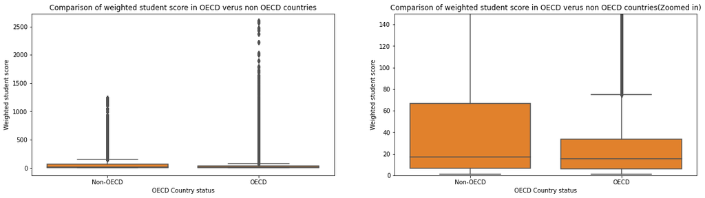

```python
# box plot of student scores versus oecd Country status
def bplot1():
    sb.boxplot(data=dfi_psi, x='OECD Country status', y='Weighted student score',color=sb.color_palette()[1])
    plt.title('Comparison of weighted student score in OECD verus non OECD countries');

# box plot of student scores versus oecd Country status with a zoom-in using the xlim functionality
def bplot2():
    sb.boxplot(data=dfi_psi, x='OECD Country status', y='Weighted student score',color=sb.color_palette()[1]);
    plt.ylim([0,150])
    plt.title('Comparison of weighted student score in OECD verus non OECD countries(Zoomed in)')

# Plotting boxplots with ylimits to expand and better undertsand data

plt.figure(figsize = [20, 5])
plt.title('Comparison of OECD versus NON-OECD countries')
plt.subplot(1, 2, 1)
bplot1()

#plotting ylimited subplot of data
plt.subplot(1, 2, 2)
bplot2()
```

**Observation**  
From the graph above it is seen that OECD countries have a relatively high amount of outliers in comparison to NON-PECD countries though the median is relatively the same.

**Question 14**  
Is there any difference in the effort that students put in to reason mathematics between males and females?  
**Visualisation :**

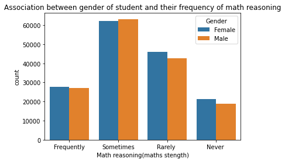

```python
# method to determine association between two categorical variables
def clusbar(x,hue,title,order):
    sb.countplot(data = dfi_psi, x = x, hue = hue,order=order)
    plt.title(title);

# drawing clustered bar chart demosntrating association between mathe reasoning effort and gender
order=['Frequently','Sometimes','Rarely ','Never ']
title='Association between gender of student and their frequency of math reasoning'
clusbar('Math reasoning(maths stength)','Gender',title,order)
```

**Observation**

From the graph above, it is seen that between the bars of those who frequently put in effort to reason mathematics and those those whop does it sometimes, the difference appears small.

**Question 15**  
How does the presence or absence of a father figure affect truancy of skipping school?  
**Visualisation :**

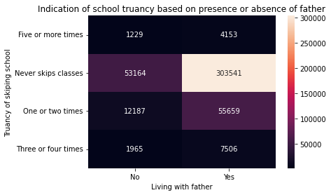

```python
# method to draw heatmap between school truancy and living with father
def heatm():
    conti=pd.crosstab(dfi_psi['Truancy of skiping school'],dfi_psi['Living with father'])
    sb.heatmap(conti,annot = True, fmt = 'd',)
    plt.title('Indication of school truancy based on presence or absence of father');

    # drawing heatmap between truancy and presence if father
heatm()
```

**Observation**  
From the heatmap above, it can be seen that a majority of students who never skip classes have father figures at their homes though there are generally more children with father figures in comparison to those without fathers.

### Talk about some of the relationships you observed in this part of the investigation. How did the feature(s) of interest vary with other features in the dataset?

We looked at the association between student's reading score and their weighted score(score which seeks to estimate their overall success rate) and saw that there was no correlation betweenthese two variables Though correlation is not same as causation, we could make conclusions towards reading ability not entirely determining student success. Further more upon accessing students weighted score between OECD and non OECD countries, we discovered that OECD countries have more outliers weighted scores. This can mean there are inherent advantages of being an OECD country hence the elevated score.

### Did you observe any interesting relationships between the other features (not the main feature(s) of interest)?

No particularly distinct observatrions were observed in our bivariate analysis as there were relatively uniform distruibutions among males and females when variables like math reasoning were assessed as seen in question 14.

## Multivariate Exploration

More than two variable exploration.

**Question 16**  
what is the outlook of a student's reading strength with their chances of repeating classes among males and females?  
**Visualisation**

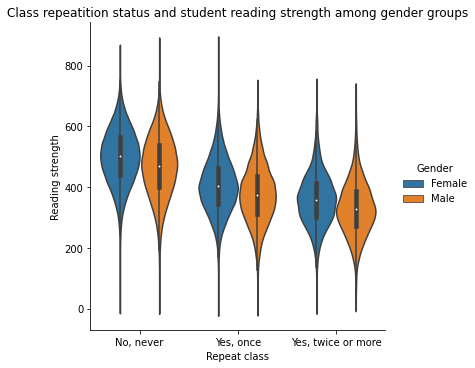

```python
# violin plot to showcase class repeatition with reading strength among males and females
sb.catplot(data=dfi_psi, y="Reading strength", x="Repeat class", hue="Gender", kind="violin")
plt.title('Class repeatition status and student reading strength among gender groups');
```

**Observation**  
From the graph above, studenst with the greatest reading strengths are seen to be the studenst who have never repeated though males are often slightly less than females across all categories.

**Question 17**  
What is the nature of correlation between studenst reading strength and their weighted score between OECD and NON-OECD countries ?  
**Visualisation**

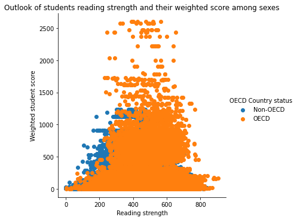

```python
# method to draw correlation chart with given categories
def corrmul(catv,v1,v2,title):
    g = sb.FacetGrid(data = dfi_psi, hue = catv, height = 5)
    g.map(plt.scatter, v1, v2)
    plt.title(title)
    g.add_legend()
# defining variables and drawing chart
catv,v1,v2= 'OECD Country status','Reading strength','Weighted student score'
title='Outlook of students reading strength and their weighted score among sexes'
corrmul(catv,v1,v2,title)
```

**Observation**  
From the graph above correlation is not very apparent but it can be observed that OECD countries have higher weighted scores above the 1500 mark.

### Were there any interesting or surprising interactions between features?

No particularly surprising interactions were observed at this level, most were anticipated from the bivariayte analysis level.

## Conclusions

```python
# saving varaibles of interest to be used for final explanatory analysi
dfi_psi.to_csv('pisa_interest.csv')
```